# Mining the C++ Standard

# Preface

```
## stdlib files:
##  lib-intro.tex support.tex diagnostics.tex utilities.tex strings.tex locales.tex containers.tex iterators.tex algorithms.tex numerics.tex iostreams.tex regex.tex atomics.tex threads.tex grammar.tex limits.tex compatibility.tex future.tex
```

```
## Observations: 123
## Variables: 11
## $ location_sec0   <fct> lib-intro.tex:2, lib-intro.tex:2, lib-intro.tex:…
## $ stem_sec0       <chr> "library", "library", "library", "library", "lib…
## $ location_sec1   <fct> lib-intro.tex:915, lib-intro.tex:915, lib-intro.…
## $ stem_sec1       <chr> "requirements", "requirements", "requirements", …
## $ location_sec2   <fct> lib-intro.tex:935, lib-intro.tex:935, lib-intro.…
## $ stem_sec2       <chr> "organization", "organization", "using", "confor…
## $ location_sec3   <fct> lib-intro.tex:977, lib-intro.tex:1287, lib-intro…
## $ stem_sec3       <chr> "headers", "compliance", "using.linkage", "reent…
## $ file_impldef    <chr> "lib-intro.tex", "lib-intro.tex", "lib-intro.tex…
## $ lineno_impldef  <chr> "1179", "1300", "1401", "2805", "2954", "2992", …
## $ content_impldef <fct> "it is \\impldef{whether functions from Annex K …
```

# Count by tex file

For now, let’s start by counting the number of impldefs per chapter!

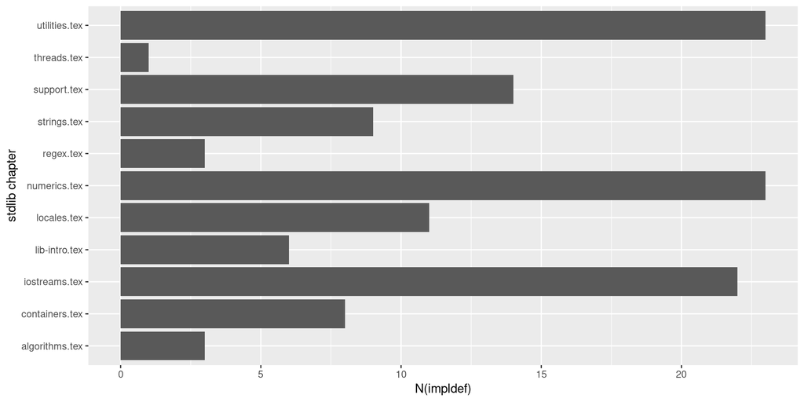

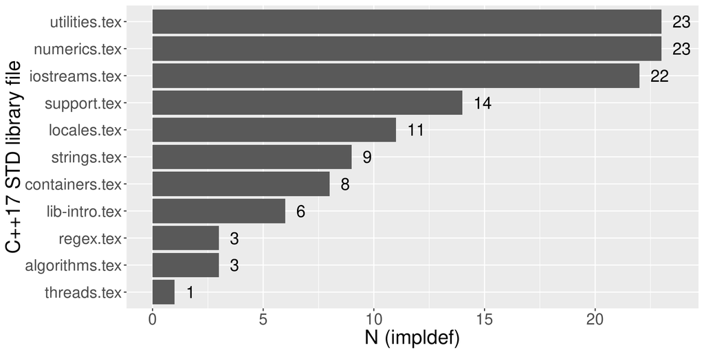

# Count by chapter stem

Next, let’s find the section stem that an impldef is contained in.

```
## Observations: 33
## Variables: 2
## $ stem_sec1 <chr> "any", "complex.numbers", "execpol", "iostream.format"…
## $ count     <int> 1, 1, 1, 1, 1, 1, 1, 2, 2, 2, 2, 2, 2, 2, 2, 3, 3, 3, …
```

```
## Observations: 108
## Variables: 2
## $ stem_sec1 <fct> library.general, library.c, definitions, description, …
## $ count     <dbl> 0, 0, 0, 0, 0, 0, 0, 0, 0, 0, 0, 0, 0, 0, 0, 0, 0, 0, …
```

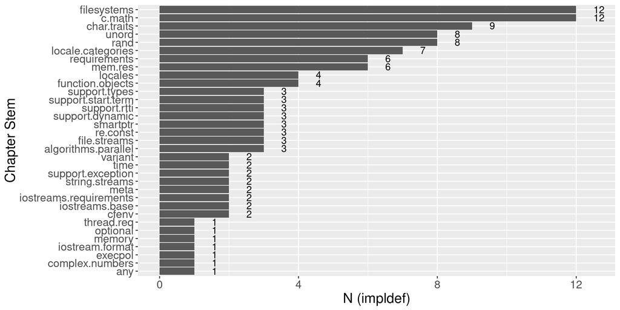

```
## [1] 33
```

```
## [1] 33
```

[figure not shown]

# Selected chapters

## unord

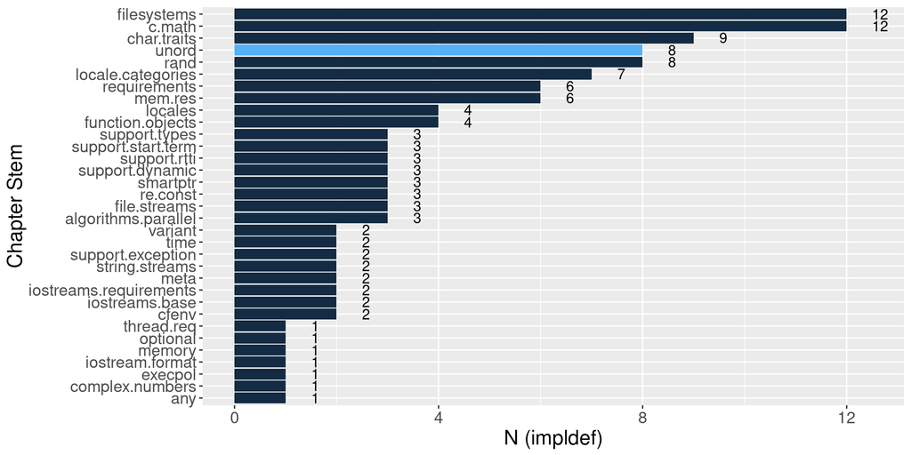

```
## [1] "unord"
```

```
## [1] "unord.map"      "unord.multimap" "unord.set"      "unord.multiset"
```

Checking the invidual impldef statements in `containers.tex` reveals, that these statements are of the type:

> `For the default constructor, the number of buckets is \impldef{default number of buckets in \tcode{unordered_set}}.`

## char.traits

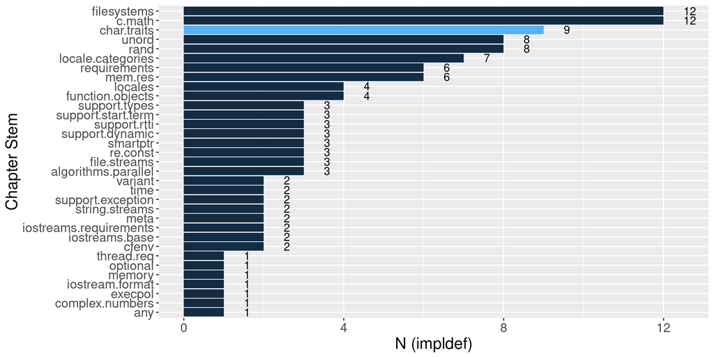

```
## [1] "char.traits"
```

```
## [1] "char.traits.specializations"
```

```
## [1] "strings.tex"
```

So checking `strings.tex` is the next step. The impldef statements here revolve around [char.traits](https://en.cppreference.com/w/cpp/string/char_traits) and how types used by these traits are defined or how Unicode can be handled.

## c.math

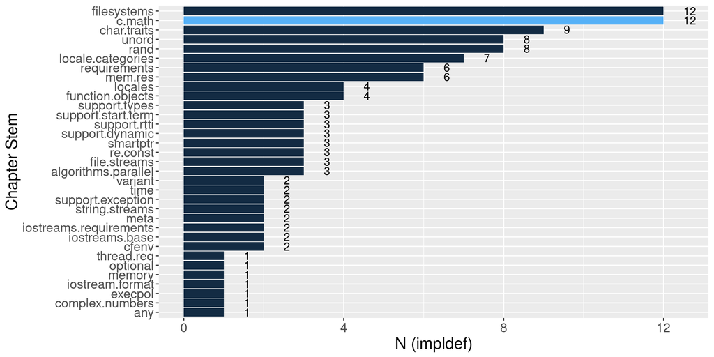

```
## [1] "c.math"
```

```
## [1] "sf.cmath"
```

```
## [1] "numerics.tex"
```

```
##    stem_sec1      location_sec2 stem_sec2      location_sec3
## 1     c.math numerics.tex:10568  sf.cmath numerics.tex:10618
## 2     c.math numerics.tex:10568  sf.cmath numerics.tex:10655
## 3     c.math numerics.tex:10568  sf.cmath numerics.tex:10822
## 4     c.math numerics.tex:10568  sf.cmath numerics.tex:10863
## 5     c.math numerics.tex:10568  sf.cmath numerics.tex:10900
## 6     c.math numerics.tex:10568  sf.cmath numerics.tex:10956
## 7     c.math numerics.tex:10568  sf.cmath numerics.tex:11134
## 8     c.math numerics.tex:10568  sf.cmath numerics.tex:11169
## 9     c.math numerics.tex:10568  sf.cmath numerics.tex:11205
## 10    c.math numerics.tex:10568  sf.cmath numerics.tex:11289
## 11    c.math numerics.tex:10568  sf.cmath numerics.tex:11327
## 12    c.math numerics.tex:10568  sf.cmath numerics.tex:11375
##                  stem_sec3 file_impldef lineno_impldef
## 1  sf.cmath.assoc_laguerre numerics.tex          10651
```

[output cut: 24 more lines]

All of these impldef statements are contained in `numerics.tex`. Most of them revolve around [specialized math functions](https://en.cppreference.com/w/cpp/numeric/special_math) and how they handle ill-posed inputs, e.g.

> `\impldef{effect of calling associated Legendre polynomials with \\tcode{l >= 128}}`

## rand

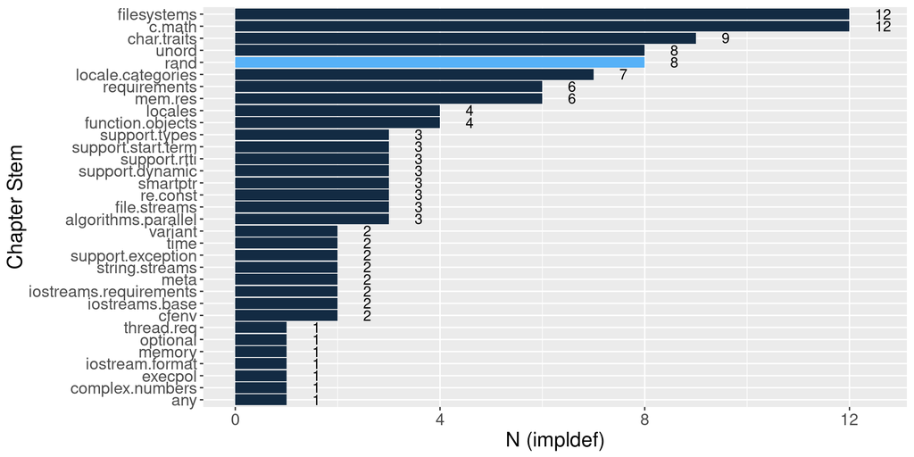

```
## [1] "rand"
```

```
## [1] "rand.predef" "rand.device" "rand.dist"   "c.math.rand"
```

```
## [1] "numerics.tex"
```

```
##   stem_sec1     location_sec2   stem_sec2     location_sec3
## 1      rand numerics.tex:3626 rand.predef   numerics.tex:-1
## 2      rand numerics.tex:3626 rand.predef   numerics.tex:-1
## 3      rand numerics.tex:3813 rand.device   numerics.tex:-1
## 4      rand numerics.tex:3813 rand.device   numerics.tex:-1
## 5      rand numerics.tex:3813 rand.device   numerics.tex:-1
## 6      rand numerics.tex:3813 rand.device   numerics.tex:-1
## 7      rand numerics.tex:4229   rand.dist numerics.tex:4232
## 8      rand numerics.tex:6386 c.math.rand   numerics.tex:-1
##           stem_sec3 file_impldef lineno_impldef
## 1              <NA> numerics.tex           3776
## 2              <NA> numerics.tex           3783
## 3              <NA> numerics.tex           3864
## 4              <NA> numerics.tex           3871
## 5              <NA> numerics.tex           3906
## 6              <NA> numerics.tex           3910
## 7 rand.dist.general numerics.tex           4255
## 8              <NA> numerics.tex           6415
##                                                                                               content_impldef
## 1                using default_random_engine = @\\textit{\\impldef{type of \\tcode{default_random_engine}}}@;
## 2                                                       is \\impldef{type of \\tcode{default_random_engine}}.
## 3  \\impldef{semantics and default value of \\tcode{token} parameter to \\tcode{random_device} constructor}.%
## 4         \\throws A value of an \\impldef{exception type when \\tcode{random_device} constructor fails} type
## 5                                    It is \\impldef{how \\tcode{random_device::operator()} generates values}
## 6              \\throws A value of an \\impldef{exception type when \\tcode{random_device::operator()} fails}
## 7                               \\impldef{algorithms for producing the standard random number distributions}.
## 8                                            It is \\impldef{whether \\tcode{rand} may introduce a data race}
```

All of these impldef statements are contained in `numerics.tex`.

## time

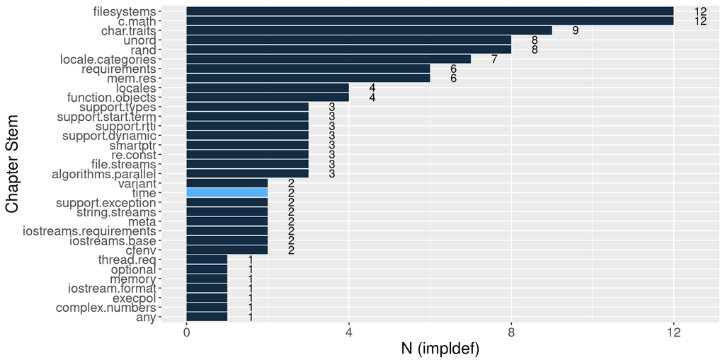

```
## [1] "time"
```

```
## [1] "time.clock"
```

```
## [1] "utilities.tex"
```

```
##   stem_sec1       location_sec2  stem_sec2       location_sec3
## 1      time utilities.tex:18888 time.clock utilities.tex:18895
## 2      time utilities.tex:18888 time.clock utilities.tex:18895
##           stem_sec3  file_impldef lineno_impldef
## 1 time.clock.system utilities.tex          18941
## 2 time.clock.system utilities.tex          18956
##                                                                                                            content_impldef
## 1 It is \\impldef{whether values are rounded or truncated to therequired precision when converting between \\tcode{time_t}
## 2 It is \\impldef{whether values are rounded or truncated to therequired precision when converting between \\tcode{time_t}
```

> `It is \\impldef{whether values are rounded or truncated to the required precision when converting between \\tcode{time_t}`

## Misc finds

- The return value of `std::pow(0.,0.)` is impldef! (numerics.tex:1199)
- often find exception types are impldef

```
## Observations: 8
## Variables: 11
## $ location_sec0   <fct> lib-intro.tex:2, support.tex:2, support.tex:2, u…
## $ stem_sec0       <chr> "library", "language.support", "language.support…
## $ location_sec1   <fct> lib-intro.tex:915, support.tex:3068, support.tex…
## $ stem_sec1       <chr> "requirements", "support.exception", "support.ex…
## $ location_sec2   <fct> lib-intro.tex:2658, support.tex:3105, support.te…
## $ stem_sec2       <chr> "conforming", "exception", "bad.exception", "uti…
## $ location_sec3   <fct> lib-intro.tex:2909, support.tex:-1, support.tex:…
## $ stem_sec3       <chr> "res.on.exception.handling", NA, NA, "util.smart…
## $ file_impldef    <chr> "lib-intro.tex", "support.tex", "support.tex", "…
## $ lineno_impldef  <chr> "2954", "3188", "3257", "9763", "9802", "14436",…
## $ content_impldef <fct> "may throw \\impldef{exceptions thrown by standa…
```

```
##           stem_sec1       location_sec2     stem_sec2       location_sec3
## 1      requirements  lib-intro.tex:2658    conforming  lib-intro.tex:2909
## 2 support.exception    support.tex:3105     exception      support.tex:-1
## 3 support.exception    support.tex:3200 bad.exception      support.tex:-1
## 4          smartptr  utilities.tex:9516 util.smartptr  utilities.tex:9545
## 5          smartptr  utilities.tex:9516 util.smartptr  utilities.tex:9545
## 6  function.objects utilities.tex:14230     func.bind utilities.tex:14417
## 7              rand   numerics.tex:3813   rand.device     numerics.tex:-1
## 8              rand   numerics.tex:3813   rand.device     numerics.tex:-1
##                   stem_sec3  file_impldef lineno_impldef
## 1 res.on.exception.handling lib-intro.tex           2954
## 2                      <NA>   support.tex           3188
## 3                      <NA>   support.tex           3257
## 4      util.smartptr.shared utilities.tex           9763
## 5      util.smartptr.shared utilities.tex           9802
## 6           func.bind.place utilities.tex          14436
## 7                      <NA>  numerics.tex           3871
## 8                      <NA>  numerics.tex           3910
##                                                                                                                content_impldef
## 1 may throw \\impldef{exceptions thrown by standard library functions that have apotentially-throwing exception specification}
## 2                                                               An \\impldef{return value of \\tcode{exception::what}} \\ntbs.
## 3                                                           An \\impldef{return value of \\tcode{bad_exception::what}} \\ntbs.
## 4                                   \\pnum\\throws \\tcode{bad_alloc}, or an \\impldef{exception type when \\tcode{shared_ptr}
## 5                                  \\pnum\\throws  \\tcode{bad_alloc}, or an \\impldef{exception type when \\tcode{shared_ptr}
## 6                                constructors shall not throw exceptions. It is \\impldef{assignability of placeholderobjects}
## 7                          \\throws A value of an \\impldef{exception type when \\tcode{random_device} constructor fails} type
## 8                               \\throws A value of an \\impldef{exception type when \\tcode{random_device::operator()} fails}
```